# VIQ - Laboratorio 6

2021-05-06

### Obiettivi

1. Creare mappe coropletiche
2. Combinare dati diversi

### Strumento

RStudio, in particolare le librerie presenti nel tidyverse (ggplot2), le librerie sf e patchwork.

### Dataset

- Shapefile dei confini amministrativi italiani, dalla pagina: https://www.istat.it/it/archivio/222527
  - Shapefile anno 2020: https://www.istat.it/storage/cartografia/confini_amministrativi/generalizzati/Limiti01012020_g.zip
  - Zip scaricato e da espandere nella cartella corrente
- Dati popolazione residente 1 Gennaio 2021 fonte ISTAT, dalla pagina: http://dati.istat.it/Index.aspx?QueryId=18460
  - File scaricato e salvato nel file CSV (`DCIS_POPRES1.csv`)
- Dati dashboard ISS su diffusione COVID-19, dalla pagina: https://www.epicentro.iss.it/coronavirus/sars-cov-2-dashboard
  - In particolare: https://www.epicentro.iss.it/coronavirus/open-data/covid_19-iss.xlsx

## Parte 1: Mappe e dati geografici

### Visualizzare mappa con i confini provinciali

Utilizzando gli shapefile relativi ai confini amministrativi delle province, dal sito ISTAT: https://www.istat.it/it/archivio/222527

- leggere e visualizzare i confini delle province

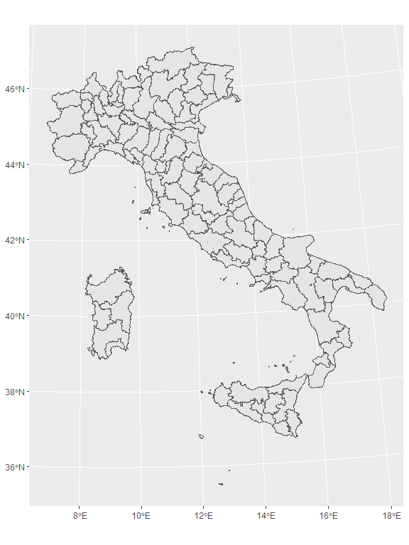

```r
### DA COMPLETARE
prov<-read_sf(shapes_prov)
prov%>%
ggplot()+geom_sf()
```

```r
NA
NA
NA
NA
```

- visualizzare all’interno di ciascuna provincia la sigla (`SIGLA`)
  - *Suggerimento:* utilizzare la funzione `geom_sf_text()` per inserire testo nella sf

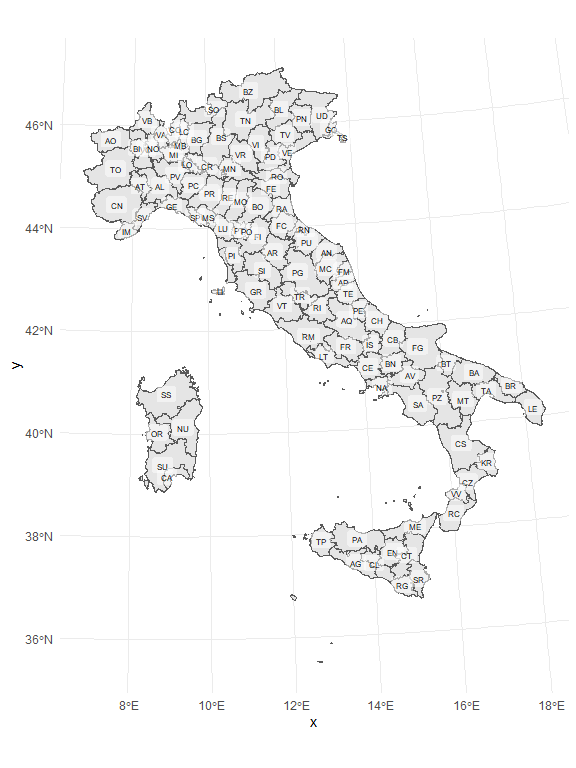

```r
## DA COMPLETARE
prov%>%
ggplot()+
  geom_sf()+
  geom_sf_label(aes(label=SIGLA), size=2, alpha=0.5, label.size = 0)+
  #un'alternativa è geom_sf_text
  #vengono generate label che hanno rettangolo e uno sfondo
  theme_minimal()
```

- aggiungere un colore di riempimento che corrisponda al tipo di entità territoriale (`TIPO_UTS`)
  - provara a variare lo schema di colori (es. `scale_fill_brewer()`)

```r
## DA COMPLETARE
prov<-prov%>%
  mutate(TIPO_UTS=as.factor(TIPO_UTS))
levels(prov$TIPO_UTS)
```

```
[1] "Citta metropolitana"        "Libero consorzio di comuni" "Provincia"                  "Provincia autonoma"
[5] "Unità non amministrativa"
```

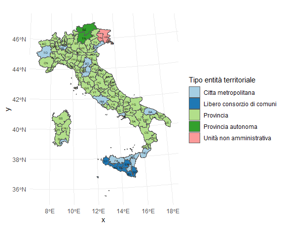

```r
prov%>%
  ggplot(aes(fill=TIPO_UTS))+geom_sf()+
    geom_sf_text(aes(label=SIGLA), size=1.5)+
  scale_fill_brewer(palette = 3, type="qual", name="Tipo entità territoriale")+
  #type è il tipo di palette che vogliamo utilizzare
  #quelle sequenziali(es. da azzurro chiaro a scuro che danno senso di ordine), divergenti (2 colori opposti, verso uno neutro al centro, va bene con ad es. temperature ). Qualitativo, non c'è un ordine, solo colori diversi tra di loro
  theme_minimal()
```

```r
NA
NA
```

### Caricare e “arrangiare” i dati di popolazione

Il file contiene il valore di popolazione (`Value`) per diverse aggregazioni:

- diverse entità territoriali (indicate da `ITTER107`)
  - `IT` intero territorio nazionale
  - `ITx` territori (es. Nord-ovest)
  - `ITx#` regioni e province autonome
  - `ITx#y` province,
- genere (`Sesso`)
  - `maschi`
  - `femmine`
  - `totale`
- diversi stati civili (`Stato civile`)
  - vari oltre a `totale`
- diverse età (`Età`)
  - `0 anni`
  - …
  - `100 anni e più`
  - `totale`
- leggere i dati relativi alla popolazione (e mostrare il dataframe)
  - *Suggerimento:* usare il metodo `read_csv()` con solo il nome del file, viene generato il codice relativo ai tipi delle colonne che può essere usato come valore per il parametro `col_types`
  - per riferirsi a nomi di colonne contenenti spazi occorre racchiuderli tra `

```r
## DA COMPLETARE
istat<-read_csv(popfile)
istat<-istat%>%
  mutate(Sesso=as_factor(Sesso) )%>%
  select(-TIPO_DATO15, -`Tipo di indicatore demografico`, -`Flag Codes`,-Flags, -TIME, -`Seleziona periodo`)

istat
```

| ITTER107 | Territorio | SEXISTAT1 | Sesso | ETA1 | Età | STATCIV2 | Stato civile | Value |
| --- | --- | --- | --- | --- | --- | --- | --- | --- |
| IT | Italia | 1 | maschi | Y0 | 0 anni | 99 | totale | 208698 |
| IT | Italia | 2 | femmine | Y0 | 0 anni | 99 | totale | 196623 |
| IT | Italia | 9 | totale | Y0 | 0 anni | 99 | totale | 405321 |
| ITC | Nord-ovest | 1 | maschi | Y0 | 0 anni | 99 | totale | 54531 |
| ITC | Nord-ovest | 2 | femmine | Y0 | 0 anni | 99 | totale | 51577 |
| ITC | Nord-ovest | 9 | totale | Y0 | 0 anni | 99 | totale | 106108 |
| ITC1 | Piemonte | 1 | maschi | Y0 | 0 anni | 99 | totale | 14055 |
| ITC1 | Piemonte | 2 | femmine | Y0 | 0 anni | 99 | totale | 13122 |
| ITC1 | Piemonte | 9 | totale | Y0 | 0 anni | 99 | totale | 27177 |
| ITC11 | Torino | 1 | maschi | Y0 | 0 anni | 99 | totale | 7387 |

[output cut: 990 more lines]

```r
NA
```

- selezionare la popolazione totale a livello di provincia (e mostrare il dataframe)
  - *Suggerimento:* per selezionare le provinci è possibile usare `nchar(ITTER107)==5`
  - *Suggerimento:* selezionare il totale per età, sesso, e stato civile

```r
## DA COMPLETARE
istat%>%
  filter(nchar(ITTER107)==5)%>%
  select(-ETA1, -'Stato civile', -STATCIV2)%>%
 pivot_wider(names_from = 'Età', values_from = Value)
```

| ITTER107 | Territorio | SEXISTAT1 | Sesso | 0 anni | 1 anni | 2 anni | 3 anni | 4 anni | 5 anni | 6 anni | 7 anni | 8 anni | 9 anni | 10 anni | 11 anni | 12 anni | 13 anni | 14 anni | 15 anni | 16 anni | 17 anni | 18 anni | 19 anni | 20 anni | 21 anni | 22 anni | 23 anni | 24 anni | 25 anni | … |
| --- | --- | --- | --- | --- | --- | --- | --- | --- | --- | --- | --- | --- | --- | --- | --- | --- | --- | --- | --- | --- | --- | --- | --- | --- | --- | --- | --- | --- | --- | --- |
| ITC11 | Torino | 1 | maschi | 7387 | 7400 | 7725 | 8272 | 8548 | 9036 | 9095 | 9550 | 9822 | 10102 | 10231 | 10545 | 10666 | 10484 | 10429 | 10316 | 10371 | 10348 | 10026 | 10106 | 10682 | 10650 | 10898 | 10642 | 10546 | 10523 | … |
| ITC11 | Torino | 2 | femmine | 6928 | 7130 | 7425 | 7898 | 8153 | 8227 | 8819 | 8855 | 9237 | 9249 | 9656 | 9746 | 9916 | 9866 | 9609 | 9768 | 9592 | 9762 | 9635 | 9606 | 9868 | 9561 | 9734 | 9863 | 9705 | 9515 | … |
| ITC11 | Torino | 9 | totale | 14315 | 14530 | 15150 | 16170 | 16701 | 17263 | 17914 | 18405 | 19059 | 19351 | 19887 | 20291 | 20582 | 20350 | 20038 | 20084 | 19963 | 20110 | 19661 | 19712 | 20550 | 20211 | 20632 | 20505 | 20251 | 20038 | … |
| ITC12 | Vercelli | 1 | maschi | 516 | 548 | 525 | 554 | 598 | 621 | 662 | 628 | 690 | 658 | 715 | 738 | 697 | 748 | 730 | 688 | 704 | 763 | 747 | 740 | 803 | 798 | 810 | 806 | 792 | 854 | … |
| ITC12 | Vercelli | 2 | femmine | 491 | 479 | 545 | 567 | 550 | 595 | 594 | 625 | 655 | 618 | 635 | 691 | 687 | 697 | 685 | 681 | 660 | 651 | 714 | 658 | 706 | 706 | 719 | 729 | 732 | 726 | … |
| ITC12 | Vercelli | 9 | totale | 1007 | 1027 | 1070 | 1121 | 1148 | 1216 | 1256 | 1253 | 1345 | 1276 | 1350 | 1429 | 1384 | 1445 | 1415 | 1369 | 1364 | 1414 | 1461 | 1398 | 1509 | 1504 | 1529 | 1535 | 1524 | 1580 | … |
| ITC13 | Biella | 1 | maschi | 448 | 461 | 473 | 516 | 562 | 561 | 601 | 627 | 678 | 618 | 676 | 674 | 721 | 764 | 765 | 765 | 746 | 797 | 779 | 740 | 829 | 802 | 836 | 828 | 792 | 771 | … |
| ITC13 | Biella | 2 | femmine | 414 | 460 | 504 | 462 | 554 | 528 | 565 | 553 | 606 | 650 | 660 | 713 | 691 | 714 | 699 | 676 | 675 | 731 | 719 | 753 | 754 | 737 | 726 | 724 | 728 | 754 | … |
| ITC13 | Biella | 9 | totale | 862 | 921 | 977 | 978 | 1116 | 1089 | 1166 | 1180 | 1284 | 1268 | 1336 | 1387 | 1412 | 1478 | 1464 | 1441 | 1421 | 1528 | 1498 | 1493 | 1583 | 1539 | 1562 | 1552 | 1520 | 1525 | … |
| ITC14 | Verbano-Cusio-Ossola | 1 | maschi | 442 | 412 | 447 | 459 | 496 | 517 | 598 | 558 | 571 | 642 | 656 | 675 | 703 | 638 | 695 | 681 | 734 | 725 | 693 | 760 | 741 | 713 | 795 | 736 | 750 | 729 | … |

[output cut: 311 more lines]

```r
#  pivot_wider(names_from = Sesso, values_from = totale)
 # pivot_wider(names_from = ETA1, values_from = Value)%>%
 # pivot_wider(names_from = , values_from = Value )
 # pivot_wider(names_from = STATCIV2, values_from = Value)
 # pivot_wider(names_from='Età')

#notato che per le province, stato civile solo totale


#fatto da lui
```

- mostrare un grafico a barre con le popolazioni delle diverse provincie

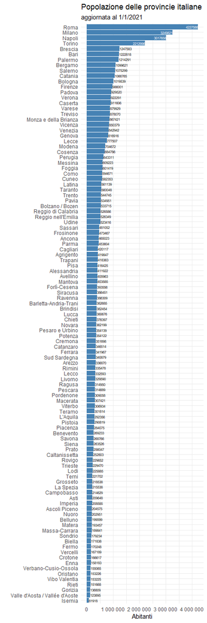

```r
#per non far stare tutti i nomi attaccati, gioca su fig.height
## DA COMPLETARE
i<-istat%>%
  filter(nchar(ITTER107)==5)%>%
  select(-ETA1, -'Stato civile', -STATCIV2)%>%
 pivot_wider(names_from = 'Età', values_from = Value)%>%
  filter(Sesso=="totale")

  ggplot(i,aes(x=totale, y=fct_reorder(Territorio, totale)))+
  geom_bar(stat="identity", fill="steelblue")+
  scale_x_continuous(labels=scales::label_number())+
  ylab("")+ #io avevo messo provincie, lui preferisce niente
  xlab("Abitanti")+
    theme(axis.text.y=element_text(size=3))+
    ggtitle("Popolazione delle provincie italiane", "aggiornata al 1/1/2021" )+
    #secondo parametro è il sottotitolo
    geom_text(aes(label=totale, color=totale>2e6 ),
              #mappato il colore su una varibile booleana che dice se la popolazione è >di 2 milioni
              hjust="inward", size=2)+
    scale_color_manual(values=c("black", "white"), guide="none")+

  theme_minimal()
```

```r
  #questi dettagli del colore e altro vanno curati se si aspira a un voto alto
```

- Verificare la corrispondenza dei dati di popolazione con quelli di confini amministrativi:
  - i dataframe hanno lo stesso numero di righe?
  - i nomi nelle colonne `DEN_UTS` e `Territorio` sono gli stessi?
  - se non lo sono: quali nomi `DEN_UTS` non hanno corrispondenza in `Territorio` e viceversa?
    - sono quelli da modificare

```r
## DA COMPLETARE

#anche lui ha usato l'approccio con %in%

#entrambi i data frame hanno 107 righe
uguali<-prov$DEN_UTS%in%i$Territorio
sum(uguali)
```

```
[1] 103
```

```r
#solo 103 corrispondono
prov$DEN_UTS[!uguali]
```

```
[1] "Aosta"         "Bolzano"       "Forli'-Cesena" "Massa Carrara"
```

```r
sort(i$Territorio)
```

```
  [1] "Agrigento"                      "Alessandria"                    "Ancona"                         "Arezzo"
  [5] "Ascoli Piceno"                  "Asti"                           "Avellino"                       "Bari"
  [9] "Barletta-Andria-Trani"          "Belluno"                        "Benevento"                      "Bergamo"
 [13] "Biella"                         "Bologna"                        "Bolzano / Bozen"                "Brescia"
 [17] "Brindisi"                       "Cagliari"                       "Caltanissetta"                  "Campobasso"
 [21] "Caserta"                        "Catania"                        "Catanzaro"                      "Chieti"
 [25] "Como"                           "Cosenza"                        "Cremona"                        "Crotone"
 [29] "Cuneo"                          "Enna"                           "Fermo"                          "Ferrara"
 [33] "Firenze"                        "Foggia"                         "Forlì-Cesena"                   "Frosinone"
 [37] "Genova"                         "Gorizia"                        "Grosseto"                       "Imperia"
 [41] "Isernia"                        "L'Aquila"                       "La Spezia"                      "Latina"
 [45] "Lecce"                          "Lecco"                          "Livorno"                        "Lodi"
 [49] "Lucca"                          "Macerata"                       "Mantova"                        "Massa-Carrara"
 [53] "Matera"                         "Messina"                        "Milano"                         "Modena"
 [57] "Monza e della Brianza"          "Napoli"                         "Novara"                         "Nuoro"
 [61] "Oristano"                       "Padova"                         "Palermo"                        "Parma"
 [65] "Pavia"                          "Perugia"                        "Pesaro e Urbino"                "Pescara"
 [69] "Piacenza"                       "Pisa"                           "Pistoia"                        "Pordenone"
 [73] "Potenza"                        "Prato"                          "Ragusa"                         "Ravenna"
 [77] "Reggio di Calabria"             "Reggio nell'Emilia"             "Rieti"                          "Rimini"
 [81] "Roma"                           "Rovigo"                         "Salerno"                        "Sassari"
 [85] "Savona"                         "Siena"                          "Siracusa"                       "Sondrio"
 [89] "Sud Sardegna"                   "Taranto"                        "Teramo"                         "Terni"
 [93] "Torino"                         "Trapani"                        "Trento"                         "Treviso"
 [97] "Trieste"                        "Udine"                          "Valle d'Aosta / Vallée d'Aoste" "Varese"
[101] "Venezia"                        "Verbano-Cusio-Ossola"           "Vercelli"                       "Verona"
[105] "Vibo Valentia"                  "Vicenza"                        "Viterbo"
```

```r
#ho usato l'operatore %in%
#uguali



#den[16]<-"Bolzano / Bozen"
#den[4]<-"Valle d'Aosta / Vallée d'Aoste"
#den[36]<-"Forlì-Cesena"
#den[53]<-"Massa-Carrara"
#uguali<-nomi%in%den
#prov$DEN_UTS<-den
```

- correggere i nomi non corrispondenti in uno dei due dataframe (e mostrare il dataframe)
  - usare la funzione `str_replace_all()` a cui è possibile passare un vettore di corrispondenze (es. `str_replace_all( col, c( "errato"="corretto"))` )

```r
## DA COMPLETARE
i<-i%>%
  mutate(Territorio=
str_replace_all(Territorio, c("Valle d'Aosta / Vallée d'Aoste"="Aosta","Bolzano / Bozen"="Bolzano","Forlì-Cesena"="Forli'-Cesena",  "Massa-Carrara"="Massa Carrara")))






uguali<-prov$DEN_UTS%in%i$Territorio
sum(uguali)
```

```
[1] 107
```

```r
#ora fa 107 e non più 103 :)
```

### Mappa coropletica

- Visualizzare la mappa coropletica delle popolazioni delle diverse province
  - *Suggerimento:* combinare i due dataframe (shapefile e popolazione regionale) tramite la funzione `inner_join(.. by="DEN_UTS"="Territorio")`
  - Provare scale di colore personalizzate:
    - `scale_fill_distiller()` ha come parametri `palette` e `direction`
    - `scale_fill_viridis_c()` ha come parametri `option` e `direction`

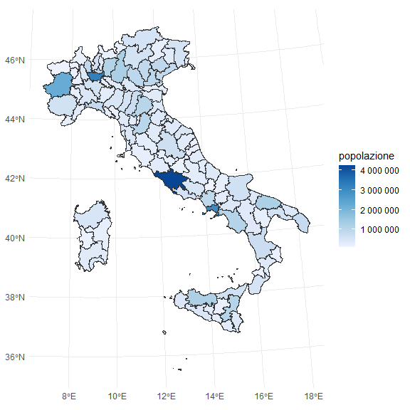

```r
## DA COMPLETARE
combinati<-prov%>%inner_join(i, by=c("DEN_UTS"="Territorio"))
combinati%>%
  ggplot(aes(fill=totale))+geom_sf(color="gray20")+
  #gray90 si applica ai confini
 # scale_fill_distiller( palette="Reds", labels=scales::label_number(), direction = 1)
 # scale_fill_viridis_c(direction = 1,labels=scales::label_number(), option="C")+

  #scale viridis fanno variare tinta e luminosità
  #(saturazione no, sono piò o meno tutti saturi)

  #in altri casi stessa tinta e si varia saturazione e luminosità
  scale_fill_distiller(labels=scales::label_number(), direction=1, name="popolazione")+
  #se uso scala logaritmica in base 10, per le label..
  #labels=function(x)as.integer(10^x/1000)
  #etichette te le devi aggiustare tu, non esiste una scala logaritmica sul fill
  #ok colori piu scuri per popolazione maggiore
  theme_minimal()
```

```r
NA
NA
NA
NA
NA
```

- aggiungere alla mappa precedente un’annotazione testuale con la popolazione (in milioni) delle 4 province più popolose

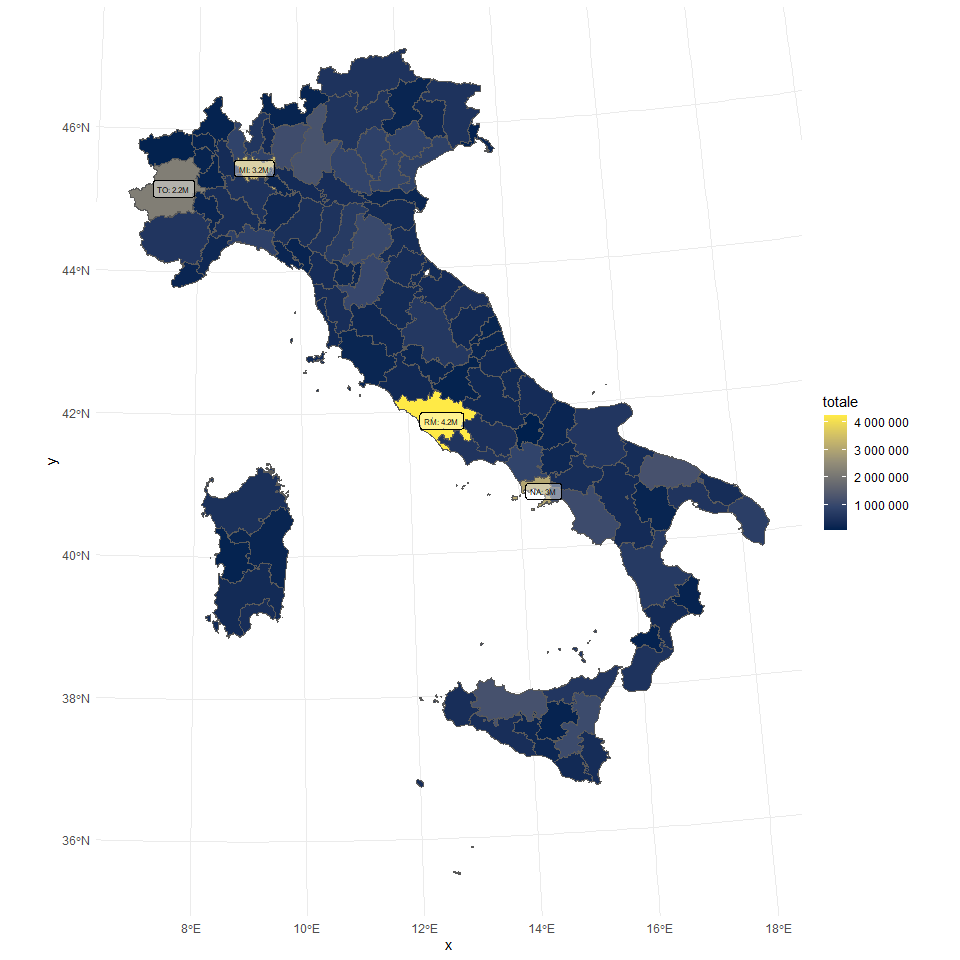

```r
## DA COMPLETARE

primiQuattro<-combinati%>%
  arrange(-totale)%>%
  top_n(4)
combinati%>%
  ggplot(aes(fill=totale))+geom_sf()+
 # scale_fill_distiller( palette="Reds", labels=scales::label_number(), direction = 1)
  scale_fill_viridis_c(direction = 1,labels=scales::label_number(), option = "E")+
      geom_sf_label(aes(label=paste0(SIGLA, ": ",round(totale/1000000,1), "M")), data=primiQuattro, size=2, color="black", fill="white", alpha=0.4)+

  theme_minimal()
```

## Parte 2: Dashboard

Partendo dai dati pubblicati nel file xlsx dall’Istituto Superio di Sanità sul monitoraggio COVID-19, ridisegnare i grafici della dashboard migliorandone i limiti.

### Dati sui casi

- leggere i dati dei casi a livello provinciale (foglio `casi_provincie`) (e mostrare il dataframe)

```r
## DA COMPLETARE
covid<-read_xlsx(fileiss, sheet="casi_provincie")
covid
```

| iss_date | COD_PROV | PROV_names | CASI_CUMULATIVI |
| --- | --- | --- | --- |
| 02/05/2021 | 1 | TORINO | 185440 |
| 02/05/2021 | 2 | VERCELLI | 12934 |
| 02/05/2021 | 3 | NOVARA | 26868 |
| 02/05/2021 | 4 | CUNEO | 49562 |
| 02/05/2021 | 5 | ASTI | 16720 |
| 02/05/2021 | 6 | ALESSANDRIA | 28336 |
| 02/05/2021 | 7 | AOSTA | 10975 |
| 02/05/2021 | 8 | IMPERIA | 14596 |
| 02/05/2021 | 9 | SAVONA | 16375 |
| 02/05/2021 | 10 | GENOVA | 53222 |

[output cut: 98 more lines]

```r
NA
```

### Mappe coropletiche

- riportare in una mappa coropletica il numero di casi per provincia

```r
## DA COMPLETARE
provincieIss<-covid$PROV_names
uguali<-tolower(combinati$DEN_UTS)%in%tolower(provincieIss)
sum(uguali)
```

```
[1] 107
```

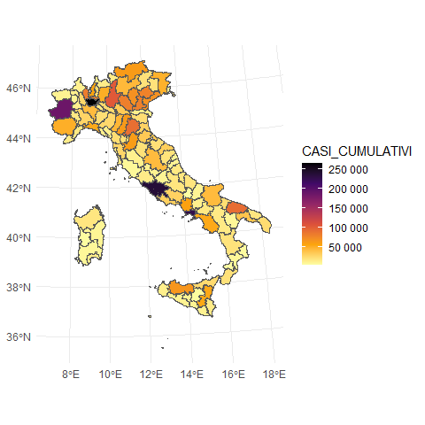

```r
#107 su 107 provincie hanno lo stesso nome, posso fare il join
combinati$DEN_UTS<-tolower(combinati$DEN_UTS)
covid$PROV_names<-tolower(covid$PROV_names)
combinati<-combinati%>%inner_join(covid, by=c("DEN_UTS"="PROV_names"))
combinati<-combinati%>%
  mutate(CASI_CUMULATIVI=as.integer(CASI_CUMULATIVI))

combinati%>%
  ggplot(aes(fill=CASI_CUMULATIVI))+geom_sf()+

  theme_minimal()+
    scale_fill_viridis_c(direction = -1,labels=scales::label_number(), option="B")
```

```r
NA
NA
NA
NA
NA
NA
```

- riportare in una mappa coropletica con l’incidenza, ovvero il numero di casi ogni 100 000 di abitanti per provincia
  - *Suggerimento:* occorre combinare gli shape con i dati dei casi e quelli della popolazione

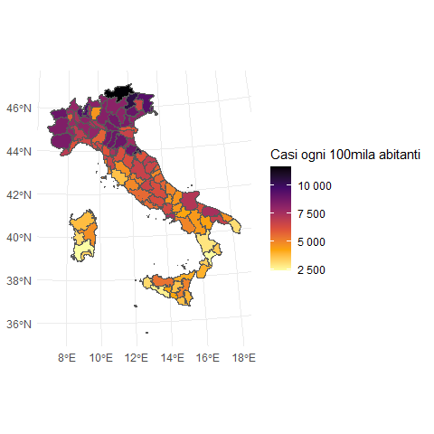

```r
## DA COMPLETARE

combinati%>%
  ggplot(aes(fill=(CASI_CUMULATIVI*100000)/totale))+
  geom_sf()+
  scale_fill_viridis_c(direction = -1,labels=scales::label_number(), option="B", guide_legend(title="Casi ogni 100mila abitanti"))+
  theme_minimal()
```

- mostrare l’incidenza (casi per 100 000 abitanti) a livello regionale
  - dati nello shapefile `Limiti01012021_g/Reg01012021_g/Reg01012021_g_WGS84.shp`

```r
## DA COMPLETARE
regioni<-read_sf(shapes_regioni)
covid_regioni<-read_xlsx(fileiss, sheet="casi_regioni")

uguali<-regioni$DEN_REG%in%covid_regioni$NOME_NUTS2
regioni$DEN_REG[!uguali]
```

```
[1] "Valle d'Aosta"         "Trentino-Alto Adige"   "Friuli Venezia Giulia"
```

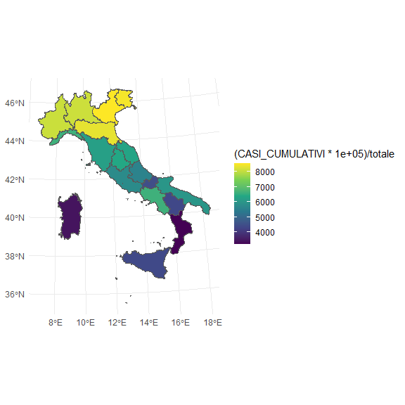

```r
regioni<-regioni%>%
  mutate(DEN_REG=
str_replace_all(regioni$DEN_REG, c("Valle d'Aosta" ="Valle d'Aosta/Vallée d'Aoste", "Friuli Venezia Giulia"=
                                     "Friuli-Venezia Giulia","Trentino-Alto Adige"= "Provincia Autonoma di Trento" )))



#uguali<-regioni$DEN_REG %in%  covid_regioni$NOME_NUTS2
#sum(uguali)
#ora tutti e 20 i nomi combaciano

combinazione_regioni<-regioni%>%
  inner_join(covid_regioni, by=c("DEN_REG"="NOME_NUTS2"))



#ti servono ora i dati sulla popolazione delle regioni


i_regioni<-istat%>%
  filter(nchar(ITTER107)==4)%>%
  select(-ETA1, -'Stato civile', -STATCIV2)%>%
 pivot_wider(names_from = 'Età', values_from = Value)%>%
  filter(Sesso=="totale")%>%
  select(Territorio, totale)


combinazione_regioni%>%inner_join(i_regioni, by=c("DEN_REG"="Territorio"))%>%
  mutate(CASI_CUMULATIVI=as.integer(CASI_CUMULATIVI))%>%
  ggplot(aes(fill=(CASI_CUMULATIVI*100000)/totale))+
  geom_sf()+
  scale_fill_viridis_c()+
  theme_minimal()
```

```r
NA
NA
NA
```

### Andamento temporale

- mostrare l’andamento temporale del numero di casi per prelievo/diagnosi e inizio sintomi
  - i dati si trovano nei fogli `casi_prelievo_diagnosi` e `casi_inizio_sintomi`
  - la media mobile puà agevolare la lettura

```r
## DA COMPLETARE

media_mobile<-function(v,n){
  stopifnot(length(v)>=n)
  #se mi dai vettore di 2 e vuoi media mobile di 3, non va bene
  res=rep(NA,floor((n-1)/2))
  #metto una serie di NA
  while(length(v)>=n){
    res=c(res, mean(v[1:n]))
    v=tail(v,-1)
    #v=v[2: length(v)]
    #lo accorcio di uno togliendo il primo elemento
  }
  res=c(res, rep(NA,floor(n/2)))
  return(res)
}
casi_prelievo_diagnosi<-read_xlsx(fileiss, sheet="casi_prelievo_diagnosi")%>%
 # mutate(DATA_PRELIEVO_DIAGNOSI=as.Date(DATA_PRELIEVO_DIAGNOSI,format("%d/%m/%Y")))%>%
  select(-iss_date)%>%
 # mutate(CASI=if_else(CASI!="<5",CASI, "3"))%>%
  mutate(CASI=as.numeric(CASI))%>%
  rename("DIAGNOSI"="CASI")%>%
  inner_join(
    read_xlsx(fileiss, "casi_inizio_sintomi")%>%
       select(-iss_date)%>%
      mutate(CASI=as.numeric(CASI))%>%
      rename("SINTOMI"="CASI") ,
    by=c("DATA_PRELIEVO_DIAGNOSI"="DATA_INIZIO_SINTOMI")


  )%>%
  rename("DATA"="DATA_PRELIEVO_DIAGNOSI")%>%
  filter(!is.na(DATA))%>%
  pivot_longer(c("SINTOMI", "DIAGNOSI"), names_to = "Tipo", values_to = "CASI")%>%
 mutate(DATA=as.Date(DATA,format("%d/%m/%Y")))%>%
  group_by(Tipo)%>%
  arrange(DATA)%>%
  mutate(CASI_MM=media_mobile(CASI,7))
```

[output not shown]

```r
casi_prelievo_diagnosi
```

| DATA | Tipo | CASI | CASI_MM |
| --- | --- | --- | --- |
| 2020-01-29 | SINTOMI | 20 | NA |
| 2020-01-29 | DIAGNOSI | NA | NA |
| 2020-02-06 | SINTOMI | 26 | NA |
| 2020-02-06 | DIAGNOSI | NA | NA |
| 2020-02-20 | SINTOMI | 408 | NA |
| 2020-02-20 | DIAGNOSI | NA | NA |
| 2020-02-21 | SINTOMI | 316 | 337.14286 |
| 2020-02-21 | DIAGNOSI | 36 | NA |
| 2020-02-22 | SINTOMI | 392 | 452.28571 |
| 2020-02-22 | DIAGNOSI | 54 | NA |

[output cut: 870 more lines]

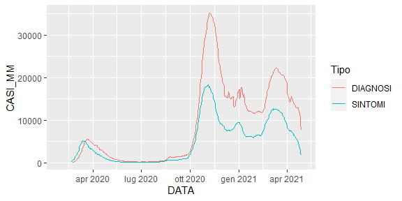

```r
casi_prelievo_diagnosi%>%ggplot(aes(x=DATA, y=CASI_MM, group=Tipo, color=Tipo))+geom_line()
```

```r
NA
NA
NA
NA
NA
NA
```

### Indicatori per fasce di età

- mostrare la distribuzione di casi per fasce di età (dati nel foglio `sesso_eta`)

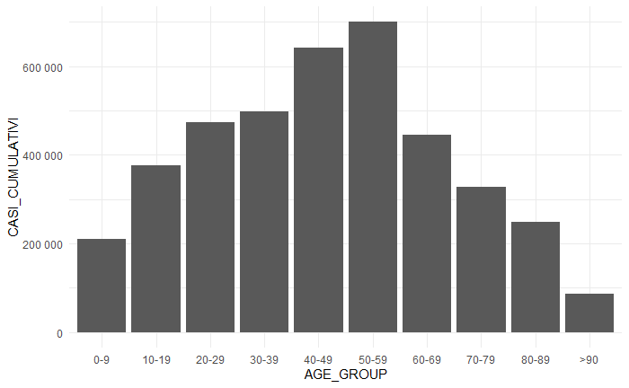

```r
## DA COMPLETARE
eta<-read_xlsx(fileiss, sheet="sesso_eta")
eta<-eta%>%
  filter(SESSO!="Non noto")%>%
  select(SESSO, AGE_GROUP, CASI_CUMULATIVI)%>%

  mutate(AGE_GROUP=as.factor(AGE_GROUP), SESSO=as.factor(SESSO), CASI_CUMULATIVI=as.integer(CASI_CUMULATIVI))%>%
  pivot_wider(names_from = SESSO, values_from = CASI_CUMULATIVI)%>%
  mutate(CASI_CUMULATIVI=F+M)%>%
  mutate(AGE_GROUP=factor(AGE_GROUP, levels = c("0-9", "10-19", "20-29", "30-39", "40-49", "50-59", "60-69", "70-79", "80-89", ">90")))%>%
  filter(AGE_GROUP!="Non noto")%>%
  select(-F,-M)

g1<-eta%>%
  ggplot(aes(x=AGE_GROUP, y=CASI_CUMULATIVI))+
  geom_bar(stat="identity")+
  scale_y_continuous(labels=scales::label_number())+
  theme_minimal()

g1
```

```r
NA
NA
NA
```

- mostrare i decessi per fasce di età

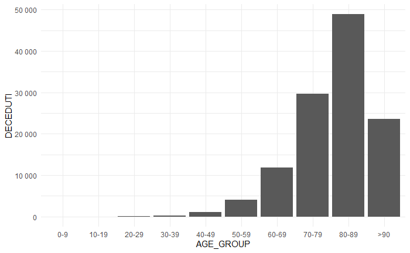

```r
## DA COMPLETARE
morte<-read_xlsx(fileiss, sheet="sesso_eta")
morte<-morte%>%
  filter(SESSO!="Non noto")%>%
  select(SESSO, AGE_GROUP, DECEDUTI)%>%

  mutate(AGE_GROUP=as.factor(AGE_GROUP), SESSO=as.factor(SESSO), DECEDUTI= if_else(DECEDUTI!="<5",DECEDUTI, "3"))%>%
  mutate(DECEDUTI=as.integer(DECEDUTI))%>%
  pivot_wider(names_from = SESSO, values_from = DECEDUTI)%>%
  mutate(DECEDUTI=F+M)%>%
  mutate(AGE_GROUP=factor(AGE_GROUP, levels = c("0-9", "10-19", "20-29", "30-39", "40-49", "50-59", "60-69", "70-79", "80-89", ">90")))%>%
 filter(AGE_GROUP!="Non noto")%>%
  select(-F,-M)

g2<-morte%>%
  ggplot(aes(x=AGE_GROUP, y=DECEDUTI))+
  geom_bar(stat="identity")+
  scale_y_continuous(labels=scales::label_number())+
  theme_minimal()

g2
```

```r
NA
NA
NA
```

- mostrare il Case Fatality Ratio (CFR), ovvero il rapporto tra i deceduti ed i casi cumulativi

```r
## DA COMPLETARE
morte
```

| AGE_GROUP | DECEDUTI |
| --- | --- |
| 0-9 | 9 |
| 10-19 | 14 |
| 20-29 | 59 |
| 30-39 | 217 |
| 40-49 | 1022 |
| 50-59 | 4060 |
| 60-69 | 11863 |
| 70-79 | 29712 |
| 80-89 | 48879 |
| >90 | 23541 |

```r
eta
```

| AGE_GROUP | CASI_CUMULATIVI |
| --- | --- |
| 0-9 | 209662 |
| 10-19 | 377243 |
| 20-29 | 473777 |
| 30-39 | 497466 |
| 40-49 | 641844 |
| 50-59 | 700419 |
| 60-69 | 445682 |
| 70-79 | 327064 |
| 80-89 | 248485 |
| >90 | 85969 |

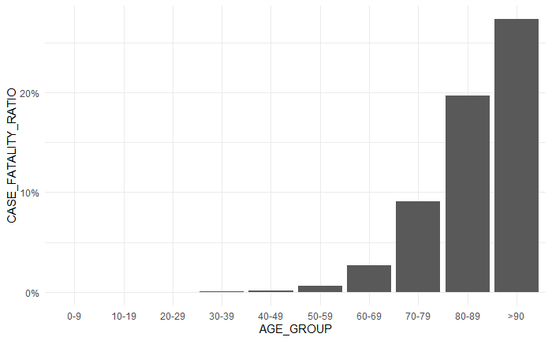

```r
cfr<-morte%>%inner_join(eta, by=c("AGE_GROUP"))
cfr<-cfr%>%
  mutate(CASE_FATALITY_RATIO=DECEDUTI/CASI_CUMULATIVI)

g3<-cfr%>%
  ggplot(aes(x=AGE_GROUP, y=CASE_FATALITY_RATIO))+
  geom_bar(stat="identity")+
  scale_y_continuous(labels=scales::label_percent())+
  theme_minimal()

g3
```

- mostrare il Tasso di Mortalità (MR), ovvero il rapporto tra i deceduti la popolazione, per fasce di età
  - Suggerimento: occorre calcolare, a partire dai dati sulla popolazione, la popolazione totale per fasce di età; per fare questo è necessario costruire una tabella di corrispondenza tra i livelli della variabile `ETA1` nei dati di popolazione e quelli della variabile `AGE_GROUP` nei dati del foglio `sesso_eta` rimuovendo i totali e i dati non noti.

  Si può sfruttare la funzione `cut()` del package di base per costruirla:

  ```
  fasce = data.frame(
      ETA1 = head( levels(popolazione$ETA1),-1),
      AGE_GROUP = cut(0:100,breaks=c(0:10*10),include.lowest=TRUE,right=FALSE,
                          labels=head(levels(covid_eta$AGE_GROUP),-1)))
  ```

  dove `head(..,-1)` toglie l’ultimo valore che corrisponde ai Totali ed ai valori non noti.

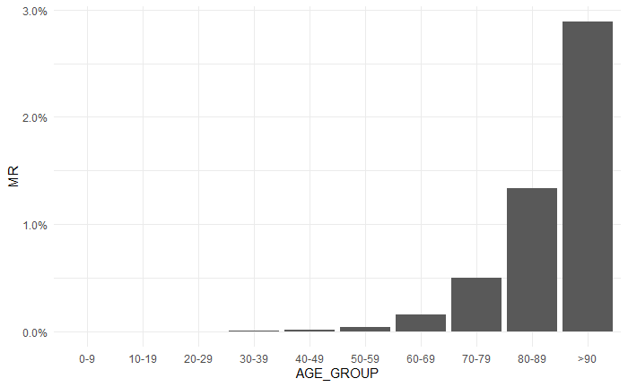

```r
## DA COMPLETARE
istat<-istat%>%
  filter(Territorio=="Italia", Sesso=="totale", ETA1!="TOTAL")%>%
  mutate(ETA1=as.character(ETA1))%>%

  mutate(ETA1=if_else(ETA1=="Y99+", "Y100", ETA1))%>%
  mutate(ETA1=as_factor(ETA1))


fasce=data.frame(
ETA1=istat$ETA1,

AGE_GROUP=cut(0:100, breaks=c(0:10*10), include.lowest = TRUE, right = FALSE,
              labels=(eta$AGE_GROUP)) )



popEta<- fasce%>%
  inner_join(istat)%>%
    group_by(AGE_GROUP)%>%
    summarise(TOTALE_POPOLAZIONE=sum(Value))
morte<-  morte%>%inner_join(popEta)%>%
    mutate(MR=DECEDUTI/TOTALE_POPOLAZIONE)
g4<-morte%>%
  ggplot(aes(x=AGE_GROUP, y=MR))+
  geom_bar(stat="identity")+
  scale_y_continuous(labels=scales::label_percent())+
  theme_minimal()


g4
```

```r
NA
```

- Combinare i quattro diagrammi precedenti in uno solo

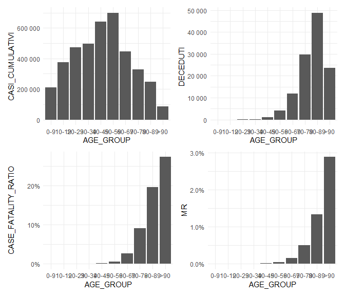

```r
## DA COMPLETARE
(g1+g2)/(g3+g4 )
```